# Statistical Inference

Master Degree

Delermando Branquinho Filho

18 de junho de 2016

### Statistical Inference Course Project

The project consists of two parts:

- A simulation exercise.
- Basic inferential data analysis.

You will create a report to answer the questions. Given the nature of the series, ideally you’ll use knitr to create the reports and convert to a pdf. (I will post a very simple introduction to knitr). However, feel free to use whatever software that you would like to create your pdf.

Each pdf report should be no more than 3 pages with 3 pages of supporting appendix material if needed (code, figures, etcetera).

## My Project

This dissertation introduces and empirically validates a new proposal in Electronic Catalogs, based on Visual One Page Catalog (VOPC) [LLW 2003][L&W 2004]. The Theory of Parallel Coordinates is the main theoretical basis for this study. The proposed interface to Electronic Catalogs based on Parallel Coordinates presents, besides filtered products on a single page, multiple attributes in only two dimensions. Among the extensions of original VOPC, it should be highlighted the use of fading and distances between attributes proportional to their relative importance degrees. To evaluate the efficiency of this new electronic catalog, two interfaces have been implemented: traditional (reference for comparison, usually found at portals in the Internet) and Parallel Coordinates. The principal objective of this study is to contribute with the improving of Electronic Catalogs in order to ease product search and choice. Specifically, efficiency (measured by the temporal duration of the search and choice process) and effort (measured by the number of clicks of the mouse) are compared in these two experimental conditions. As result of the (descriptive and inferential) statistical analysis and data interpretation, the equivalence between traditional and Parallel Coordinates was obtained, even being the last one less familiar. Hypothetically, as the proposed system becomes more familiar, favorable significant differences could happen in future experiments.

**Key words:** Electronic Catalogs, Parallel Coordinates, Internet.

## Age Distribution Subject

### Dataset

you can load the Dataset, [click here](https://www.sugarsync.com/pf/D481743_06742699_7353715)

```r
yearsoldsubjects <- read.csv("yearsoldsubjects.txt",header = FALSE)
head(yearsoldsubjects)
```

```
##   V1
## 1 50
## 2 50
## 3 50
## 4 50
## 5 50
## 6 50
```

```r
tail(yearsoldsubjects)
```

```
##    V1
## 56 45
## 57 45
## 58 45
## 59 45
## 60 45
## 61 45
```

```r
colnames(yearsoldsubjects)<-"yo"
```

### The Histogram

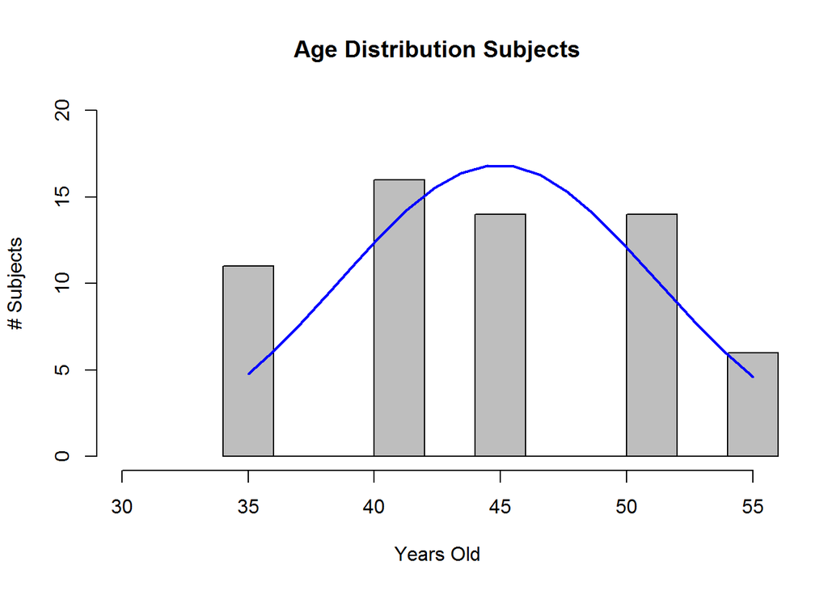

```r
h<-hist(yearsoldsubjects$yo,xlab = "Years Old", ylab =  "# Subjects",main = "Age Distribution Subjects",freq = TRUE,col = "GRAY",ylim = c(0,20), xlim = c(30,55),breaks = 8,right = FALSE)
xfit<-seq(min(yearsoldsubjects$yo),max(yearsoldsubjects$yo),length=20)
yfit<-dnorm(xfit,mean=mean(yearsoldsubjects$yo),sd=sd(yearsoldsubjects$yo))
yfit<-yfit*xfit*6
lines(xfit, yfit, col="blue", lwd=2)
```

## Distribution of the experience

This graphicas show the Distribution of the experience in selecttions of accommodations and its attributes on beaches.

### Dataset

you can load the Dataset, [click here](https://www.sugarsync.com/pf/D481743_06742699_7353887)

```r
yearsexpsubjects <- read.csv("yearsexpsubjects.txt",header = FALSE)
head(yearsexpsubjects)
```

```
##   V1
## 1  3
## 2  3
## 3  3
## 4  3
## 5  3
## 6  3
```

```r
tail(yearsexpsubjects)
```

```
##    V1
## 59  8
## 60  8
## 61  8
## 62  8
## 63  8
## 64  8
```

```r
colnames(yearsexpsubjects)<-"yo"
```

### The Histogram

Atention: run install.packages(“htmlTable”), next lines I use this library.

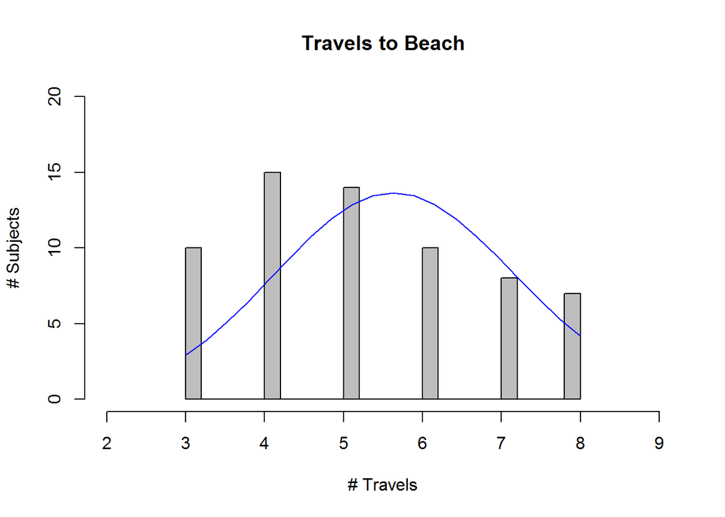

```r
library(htmlTable)
getmode <- function(v) {
   uniqv <- unique(v)
   uniqv[which.max(tabulate(match(v, uniqv)))]
}

h<-hist(yearsexpsubjects$yo,xlab = "# Travels", ylab =  "# Subjects",main = "Travels to Beach",freq = TRUE,col = "GRAY",ylim = c(0,20), xlim = c(2,9),breaks = 20,right = FALSE)
xfit<-seq(min(yearsexpsubjects$yo),max(yearsexpsubjects$yo),length=20)
yfit<-dnorm(xfit,mean=mean(yearsexpsubjects$yo),sd=sd(yearsexpsubjects$yo))
yfit<-yfit*xfit*10
lines(xfit, yfit, col="blue", lwd=1)
```

```r
idade<-c(mean(yearsoldsubjects$yo), sd(yearsoldsubjects$yo), median(yearsoldsubjects$yo), getmode(yearsoldsubjects$yo), max(yearsoldsubjects$yo), min(yearsoldsubjects$yo))

viagem<-c(mean(yearsexpsubjects$yo), sd(yearsexpsubjects$yo), median(yearsexpsubjects$yo), getmode(yearsexpsubjects$yo), max(yearsexpsubjects$yo), min(yearsexpsubjects$yo))
idade<-round(idade, digits = 2)
viagem<-round(viagem, digits = 2)

myTable <- matrix(c(idade,viagem), ncol=6, byrow = TRUE)

htmlTable(myTable, header = c("mean","sd","median","hiFrenq","max","min"),
          rnames = c("Age", "Travel"),
          caption="Descriptive analysis of the age, number of trips of the subjects",
          tfoot="Table 4.1 from Master Degree Disertation")
```

| Descriptive analysis of the age, number of trips of the subjects | Descriptive analysis of the age, number of trips of the subjects mean | Descriptive analysis of the age, number of trips of the subjects sd | Descriptive analysis of the age, number of trips of the subjects median | Descriptive analysis of the age, number of trips of the subjects hiFrenq | Descriptive analysis of the age, number of trips of the subjects max | Descriptive analysis of the age, number of trips of the subjects min |
| --- | --- | --- | --- | --- | --- | --- |
| Age | 44.02 | 6.31 | 45 | 40 | 55 | 35 |
| Travel | 5.19 | 1.58 | 5 | 4 | 8 | 3 |

Table 4.1 from Master Degree Disertation

[The Scientist BR](http://www.thescientist.com.br)